# The Future of Transfer Prices of Professional Soccer Players

## Fall 2024 Data Science Project

## Introduction

The history of market values for soccer players is an extremely interesting topic to analyze, as it can give insights into the popularity of the sport, the commercial success of the sport by region, inflation, as well as a multitude of other factors that provide fascinating paths to explore.

My project aims to find the trends in players transfer values since 2003, exploring the intricacies that a dataset like this provides. In doing so, I hope to utilize a linear regression model to generate predictions on what the future might hold for these market valuations on the small (specific teams or leagues) and large (entire dataset) scale.

## Data Curation

My data was sourced from https://www.kaggle.com/datasets/davidcariboo/player-scores/data, which pulls its data from https://www.transfermarkt.co.uk/ which is a highly respected and utilized tool in the soccer community when it comes to transfer data.

The specific data from this dataset that we want to look at is the transfer data, which includes information about all transfers that have taken place, like what team they were sold from and what team purchased them. On top of this, it includes the transfer fee as well as the market valuation estimate at the time of the transfer.

First, let's include our imports for the project,  
Pandas, Numpy, Matplotlib's Pyplot, Datetime, Scipy, and Seaborn

```python
# Imports
import pandas as pd
import numpy as np
import matplotlib.pyplot as plt
from datetime import datetime
from scipy import stats
import seaborn as sea

import warnings
# Ignore warnings for better visuals
warnings.filterwarnings('ignore')
```

Now, let's load in the data from Transfermarkt into a Pandas DataFrame to allow for easier parsing. After loading the data into the DataFrame, let's also clean the date of transfers to just the year for more clear analysis later on.

```python
# Load the data into DataFrames
transfer_df = pd.read_csv("transfers.csv")
# Clean transfer_date column for better parsing
transfer_df['transfer_date'] = transfer_df['transfer_date'].apply(lambda x: datetime.strptime(str(x), '%Y-%m-%d').year)
```

After loading it into the transfer_df variable and cleaning the transfer_date, we can see that our DataFrame looks like this

```python
transfer_df
```

|  | player_id | transfer_date | transfer_season | from_club_id | to_club_id | from_club_name | to_club_name | transfer_fee | market_value_in_eur | player_name |
| --- | --- | --- | --- | --- | --- | --- | --- | --- | --- | --- |
| 0 | 195778 | 2026 | 25/26 | 79 | 27 | VfB Stuttgart | Bayern Munich | 0.0 | 12000000.0 | Alexander Nübel |
| 1 | 569033 | 2026 | 25/26 | 39 | 27 | 1.FSV Mainz 05 | Bayern Munich | 0.0 | 4000000.0 | Armindo Sieb |
| 2 | 626913 | 2026 | 25/26 | 398 | 380 | Lazio | Salernitana | 0.0 | 15000000.0 | Boulaye Dia |
| 3 | 1047109 | 2026 | 25/26 | 2672 | 265 | APO Levadiakos | Panathinaikos | 0.0 | 100000.0 | Georgios Katris |
| 4 | 360791 | 2025 | 25/26 | 6418 | 1030 | Panetolikos | Argentinos Jrs. | 0.0 | 1200000.0 | Lucas Chaves |
| ... | ... | ... | ... | ... | ... | ... | ... | ... | ... | ... |
| 78032 | 35207 | 1995 | 95/96 | 42281 | 11896 | PTSV Dort. Yth. | Dortmund Yth. | 0.0 | NaN | Marco Reus |
| 78033 | 22141 | 1994 | 94/95 | 59178 | 29463 | Castellammare | Sorrento Youth | NaN | NaN | Antonio Mirante |
| 78034 | 33829 | 1994 | 94/95 | 58405 | 53957 | FC Penafiel You | Sporting Yth. | NaN | NaN | José Fonte |
| 78035 | 40680 | 1994 | 94/95 | 47320 | 47318 | Lichtenw. Yth. | Schornbach Yth. | 0.0 | NaN | Sven Ulreich |
| 78036 | 61989 | 1993 | 93/94 | 55345 | 55343 | A. Ickern Yth. | VfR Rauxel Yth. | 0.0 | NaN | Michael Esser |

78037 rows × 10 columns

## Exploratory Data Analysis

What columns are present in the data from Transfermarkt that we can explore?

```python
transfer_df.columns
```

```
Index(['player_id', 'transfer_date', 'transfer_season', 'from_club_id',
       'to_club_id', 'from_club_name', 'to_club_name', 'transfer_fee',
       'market_value_in_eur', 'player_name'],
      dtype='object')
```

How many rows in the dataset?

```python
len(transfer_df)
```

```
78037
```

What are the general statistics on the numerical data present in the dataset?

```python
transfer_df.describe().apply(lambda x: x.apply(lambda y: format(y, 'g')))
```

|  | player_id | transfer_date | from_club_id | to_club_id | transfer_fee | market_value_in_eur |
| --- | --- | --- | --- | --- | --- | --- |
| count | 78037 | 78037 | 78037 | 78037 | 50815 | 48288 |
| mean | 416179 | 2018.39 | 17035.5 | 12844.4 | 1.10718e+06 | 2.45837e+06 |
| std | 264628 | 4.61898 | 23258.2 | 20302 | 5.25674e+06 | 5.88058e+06 |
| min | 3333 | 1993 | 1 | 1 | 0 | 10000 |
| 25% | 204045 | 2016 | 862 | 601 | 0 | 200000 |
| 50% | 366217 | 2019 | 6676 | 3001 | 0 | 600000 |
| 75% | 586982 | 2022 | 24140 | 14648 | 0 | 2e+06 |
| max | 1.3098e+06 | 2026 | 124917 | 124917 | 1.8e+08 | 1.8e+08 |

Let's start with some simple Exploratory Data Analysis. Say we want to see the average transfer value over the entire timespan of the dataset we have, can do so with Pyplot:

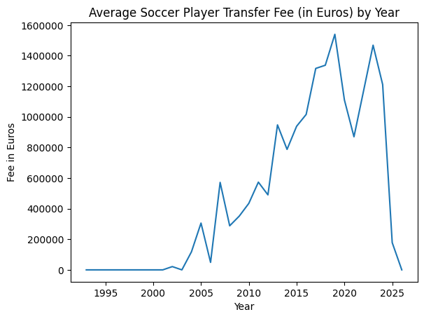

```python
groups = transfer_df[['transfer_date', 'transfer_fee']].groupby('transfer_date')
plt.ticklabel_format(style='plain')
plt.title("Average Soccer Player Transfer Fee (in Euros) by Year")
plt.xlabel("Year")
plt.ylabel("Fee in Euros")
plt.plot(groups.mean())
```

This is an interesting visualization of the general trend in price of transfer values in soccer, as it even shows the dip following 2020 from the COVID-19 pandemic. However, there is quite a bit of nuance to this graph, such as large amounts of free transfers (counted as 0) weighing down the transfer value averages and even data points that are set in the future as they've been agreed in advance (small amounts of 2025 and 2026 data). Instead of awkwardly working around that data, we will instead develop a test to see if transfer values have changed significantly over spans of 10 years. As such, we will be looking at two groups, 2003-2013, and 2014-2024, and performing a T-Test to see if there is a significant difference between the mean of the two groups.

For our first statistical method with hypothesis testing, we're going to perform a Two sample T-Test between the two groups to see if there is a statistically significant difference between the means of their transfer fees.

Null Hypothesis: There is not a significant difference between the means of the transfer fees for the 2003-2013 group and the 2014-2024 group

Alternative Hypothesis: There is a significant difference between the means of the transfer fees for the 2003-2013 group and the 2014-2024 group.

Significance level: 5% or 0.05

```python
# Ignore the warnings generated by these
earlier_group = transfer_df.dropna(subset=['transfer_fee'])[transfer_df['transfer_date'] >= 2003][transfer_df['transfer_date'] <= 2013][transfer_df['transfer_fee'] > 0]
later_group = transfer_df.dropna(subset=['transfer_fee'])[transfer_df['transfer_date'] >= 2014][transfer_df['transfer_date'] <= 2024][transfer_df['transfer_fee'] > 0]

# Calculate T-Test results
stats.ttest_ind(earlier_group['transfer_fee'], later_group['transfer_fee'])
```

```
TtestResult(statistic=-5.55097813222592, pvalue=2.9199024490143453e-08, df=9171.0)
```

```
[]
```

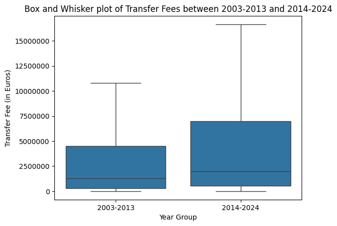

```python
earlier_group['group'] = "2003-2013"
later_group['group'] = "2014-2024"

both_groups = pd.concat([earlier_group, later_group])
plt.ticklabel_format(style='plain')
ax = sea.boxplot(x='group', y='transfer_fee', data=both_groups, showfliers=False)
plt.title("Box and Whisker plot of Transfer Fees between 2003-2013 and 2014-2024")
plt.xlabel("Year Group")
plt.ylabel("Transfer Fee (in Euros)")
plt.plot()
```

We can clearly visually see there is a difference between the two groups, which is backed up by our T-Test result previously mentioned.

Moving on to the second statistical method with hypothesis testing, I am going to use a Paired Sample T-Test to check if there is a relation in the means of the transfer fees that were paid for players and their market value.

Null Hypothesis: There is no relation in the means between a player's transfer fee and their market value.

Alternative Hypothesis: There is a relation in the means between a player's transfer fee and their market value.

Significance level: 5% or 0.05

```python
# We can only check this on players with both a transfer fee and market value listed in the data, thus we will make sure of this before testing
fee_vs_value = transfer_df.dropna(subset=['transfer_fee', 'market_value_in_eur'])[transfer_df['transfer_fee'] > 0]
stats.ttest_rel(fee_vs_value['transfer_fee'], fee_vs_value['market_value_in_eur'])
```

```
TtestResult(statistic=11.94838046523103, pvalue=1.2022998219806716e-32, df=8564)
```

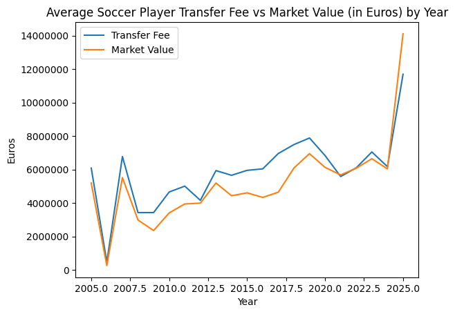

```python
# Group by year for easier to follow visualization
fee_groups = fee_vs_value[['transfer_date', 'transfer_fee']].groupby('transfer_date')
market_groups = fee_vs_value[['transfer_date', 'market_value_in_eur']].groupby('transfer_date')
plt.ticklabel_format(style='plain')
plt.title("Average Soccer Player Transfer Fee vs Market Value (in Euros) by Year")
plt.xlabel("Year")
plt.ylabel("Euros")
plt.plot(fee_groups.mean(), label=("Transfer Fee"))
plt.plot(market_groups.mean(), label=("Market Value"))
plt.legend(loc="upper left")
plt.show()
```

For the third statistical method with hypothesis testing, I am going to run an ANOVA test to see if there is a significant difference in the transfer fees paid by 3 specific teams over the span of this dataset to find out if these 3 teams, who are all in the same league, have had largely the same spending over the time period or if there is a statistically significant difference between any of the groups (teams). The three groups (teams) I will be choosing are Liverpool (the team I support), Manchester United, and Chelsea.

Null Hypothesis: There is no difference in average spending between the 3 groups.

Alternative Hypothesis: There is a difference in the average spending between the 3 groups.

Significance level: 5% or 0.05

```python
liverpool = transfer_df.dropna(subset=['transfer_fee'])[transfer_df['to_club_name'] == "Liverpool"][['transfer_fee', 'from_club_name', 'transfer_date']]
man_utd = transfer_df.dropna(subset=['transfer_fee'])[transfer_df['to_club_name'] == "Man Utd"][['transfer_fee', 'from_club_name' , 'transfer_date']]
chelsea = transfer_df.dropna(subset=['transfer_fee'])[transfer_df['to_club_name'] == "Chelsea"][['transfer_fee', 'from_club_name' , 'transfer_date']]

# ANOVA test
stats.f_oneway(liverpool['transfer_fee'], man_utd['transfer_fee'], chelsea['transfer_fee'])
```

```
F_onewayResult(statistic=1.794507551185797, pvalue=0.16726127609215483)
```

```python
# Get rid of free transfers from the data
liverpool = liverpool[liverpool['transfer_fee'] > 0]
man_utd = man_utd[man_utd['transfer_fee'] > 0]
chelsea = chelsea[chelsea['transfer_fee'] > 0]

# ANOVA test
stats.f_oneway(liverpool['transfer_fee'], man_utd['transfer_fee'], chelsea['transfer_fee'])
```

```
F_onewayResult(statistic=5.467875123203364, pvalue=0.005005203108145005)
```

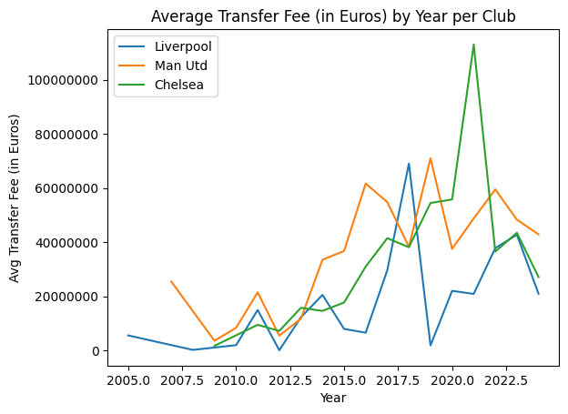

```python
# Create 3 line visualization
liverpool_group = liverpool[['transfer_date', 'transfer_fee']].groupby('transfer_date')
man_utd_group = man_utd[['transfer_date', 'transfer_fee']].groupby('transfer_date')
chelsea_group = chelsea[['transfer_date', 'transfer_fee']].groupby('transfer_date')
plt.ticklabel_format(style='plain')
plt.title("Average Transfer Fee (in Euros) by Year per Club")
plt.xlabel("Year")
plt.ylabel("Avg Transfer Fee (in Euros)")
plt.plot(liverpool_group.mean(), label=("Liverpool"))
plt.plot(man_utd_group.mean(), label=("Man Utd"))
plt.plot(chelsea_group.mean(), label=("Chelsea"))
plt.legend(loc="upper left")
plt.show()
```

With this visualization, we can tell that there are certainly difference between groups average spending. Perhaps the most glaring difference is between Liverpool and Chelsea around the time of 2019-2021. While there are some general trends that you can see that hold true between the different groups, we can also clearly see that the three groups do not all follow the same patterns as each other, which is backed up by our ANOVA test.

## Primary Analysis

Based on what we've seen from the Exploratory Data Analysis, let's train some regression models to make predictions on the transfer values of players in the near future.

First, we need to import all the libraries we will need for the regression

```python
# Additional imports for Regression analysis
from sklearn.model_selection import train_test_split
from sklearn.linear_model import LinearRegression
```

The first predictions we want to make with linear regression are going to be at the team level, i.e. looking at the transfer history of an individual team and using their transfer fees of incoming players to make predictions on how much they may spend in future years. In this tutorial, I will use Liverpool as the individual team, but feel free to choose whatever team you'd like if you want to explore another one.

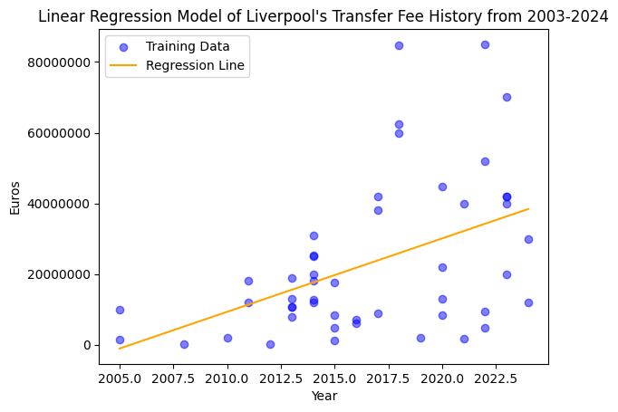

```python
# Variable setup
liverpool_data = liverpool[transfer_df['transfer_date'] >= 2003][transfer_df['transfer_date'] <= 2024]
liverpool_data = liverpool_data[['transfer_fee', 'transfer_date']]
# Polynomial Linear Model for individual team
liv_X = np.array(liverpool_data['transfer_date']).reshape(-1, 1)
liv_y = np.array(liverpool_data['transfer_fee']).reshape(-1, 1)
# Fit the model
liverpool_regression_model = LinearRegression().fit(liv_X, liv_y)
liv_Y_train_pred = liverpool_regression_model.predict(liv_X)
# Plot the results
plt.scatter(liv_X, liv_y, color='blue', label='Training Data', alpha=0.5)
plt.plot(liv_X, liv_Y_train_pred, color='orange', label='Regression Line')
plt.ticklabel_format(style='plain')
plt.title("Linear Regression Model of Liverpool's Transfer Fee History from 2003-2024")
plt.xlabel("Year")
plt.ylabel("Euros")
plt.legend()
plt.show()
```

Now let's expand the plot to see how the model predicts the average price of a signing for Liverpool over the next 10 years after 2024:

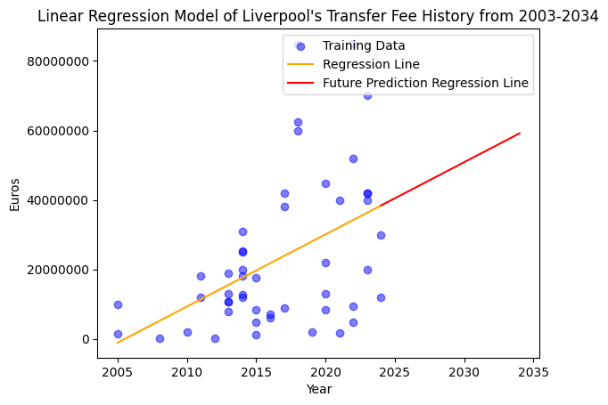

```python
# Create an array to predict the next 10 years with
next_ten = np.array([2024, 2025, 2026, 2027, 2028, 2029, 2030, 2031, 2032, 2033, 2034]).reshape(-1,1)
liv_Y_train_ten = liverpool_regression_model.predict(next_ten)

# Expanding the plot
plt.scatter(liv_X, liv_y, color='blue', label='Training Data', alpha=0.5)
plt.plot(liv_X, liv_Y_train_pred, color='orange', label='Regression Line')
plt.plot(next_ten, liv_Y_train_ten, color='red', label='Future Prediction Regression Line')
plt.ticklabel_format(style='plain')
plt.title("Linear Regression Model of Liverpool's Transfer Fee History from 2003-2034")
plt.xlabel("Year")
plt.ylabel("Euros")
plt.legend()
plt.show()
```

This model gives us an interesting first look at what our final model might look like, but the keen eyed among you will realize that this sample size is realistically too small to base any accurate wide ranging conclusions on. Let's now take one step up to the league level, including 20 teams in our sample size. We're going to take a look at the English Premier League, widely regarded as the best league in the world.

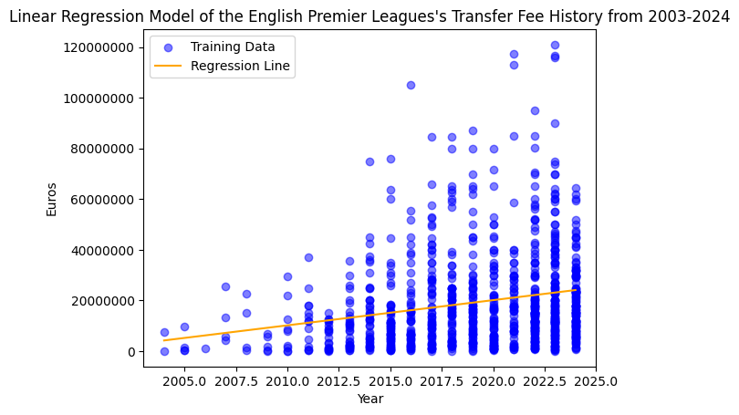

```python
# Variable setup
prem_teams = ["Liverpool", "Arsenal", "Chelsea", "Brighton", "Man City", "Nottm Forest", "Tottenham", "Brentford", "Man Utd", "Fulham", "Newcastle", "Aston Villa", "Bournemouth", "West Ham", "Everton", "Leicester", "Crystal Palace", "Wolves", "Ipswich", "Southampton"]
premier_league_data = transfer_df.dropna(subset=['transfer_fee'])[transfer_df['to_club_name'].isin(prem_teams)][['transfer_fee', 'transfer_date']]
premier_league_data = premier_league_data[premier_league_data['transfer_fee'] > 0][premier_league_data['transfer_date'] >= 2003][premier_league_data['transfer_date'] <= 2024]
# Polynomial Linear Model for individual league
prem_X = np.array(premier_league_data['transfer_date']).reshape(-1, 1)
prem_y = np.array(premier_league_data['transfer_fee']).reshape(-1, 1)

# Fit the model
premier_league_regression_model = LinearRegression().fit(prem_X, prem_y)
prem_Y_train_pred = premier_league_regression_model.predict(prem_X)
# Plot the results
plt.scatter(prem_X, prem_y, color='blue', label='Training Data', alpha=0.5)
plt.plot(prem_X, prem_Y_train_pred, color='orange', label='Regression Line')
plt.ticklabel_format(style='plain')
plt.title("Linear Regression Model of the English Premier Leagues's Transfer Fee History from 2003-2024")
plt.xlabel("Year")
plt.ylabel("Euros")
plt.legend()
plt.show()
```

Now let's expand the plot to see how the model predicts the average price of a signing for the English Premier League over the next 10 years after 2024:

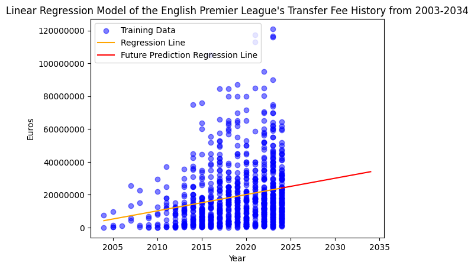

```python
prem_Y_train_ten = premier_league_regression_model.predict(next_ten)

# Expanding the plot
plt.scatter(prem_X, prem_y, color='blue', label='Training Data', alpha=0.5)
plt.plot(prem_X, prem_Y_train_pred, color='orange', label='Regression Line')
plt.plot(next_ten, prem_Y_train_ten, color='red', label='Future Prediction Regression Line')
plt.ticklabel_format(style='plain')
plt.title("Linear Regression Model of the English Premier League's Transfer Fee History from 2003-2034")
plt.xlabel("Year")
plt.ylabel("Euros")
plt.legend()
plt.show()
```

Once more, this model gives us some very intriguing insight into what our final model might look like, and as we can see the predictions are significantly lower, but once again there are some limitations to this sample. As previously mentioned, we have selected what most would consider to be the biggest league in the world, and certainly the league with the most commercial success. Using this data is going to heavily skew our results to be higher, as the teams in this league are able to spend significantly more money than the smaller leagues across the world. Now, let's instead take a look at some analysis from the overall dataset which we are going to base our final model on.

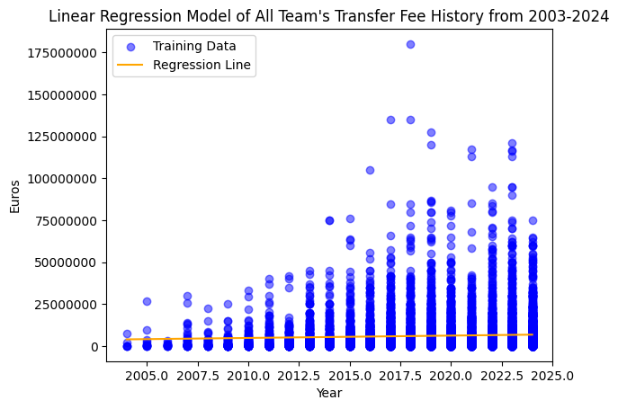

```python
all_teams_data = transfer_df.dropna(subset=['transfer_fee'])[['transfer_fee', 'transfer_date']]
all_teams_data = all_teams_data[all_teams_data['transfer_fee'] > 0][all_teams_data['transfer_date'] >= 2003][all_teams_data['transfer_date'] <= 2024]
# Polynomial Linear Model for entire dataset
all_X = np.array(all_teams_data['transfer_date']).reshape(-1, 1)
all_y = np.array(all_teams_data['transfer_fee']).reshape(-1, 1)

# Fit the model
all_teams_regression_model = LinearRegression().fit(all_X, all_y)
all_Y_train_pred = all_teams_regression_model.predict(all_X)
# Plot the results
plt.scatter(all_X, all_y, color='blue', label='Training Data', alpha=0.5)
plt.plot(all_X, all_Y_train_pred, color='orange', label='Regression Line')
plt.ticklabel_format(style='plain')
plt.title("Linear Regression Model of All Team's Transfer Fee History from 2003-2024")
plt.xlabel("Year")
plt.ylabel("Euros")
plt.legend()
plt.show()
```

Wow, at first glance that seems like the model isn't growing very much year on year. However, if you take a closer look at the scale you can see that some extreme values are making the scale of the graph quite large. Let's look at the predicted transfer value from the start of the selected data (2003) to the predicted transfer value from the end of the selected data (2024)

```python
# Return an array of the Linear Regression Model's predictions for 2003 and 2024
all_teams_regression_model.predict(np.array([2003, 2024]).reshape(-1,1))
```

```
array([[3824460.48061502],
       [6766813.90152407]])
```

As you can see, in 2003 the model estimates that a transfer would cost roughly 3.8 million Euros, whereas in 2024, it estimates around 6.7 million Euros. This model immediately feels much more reasonable than the previous ones, as the growth rate is seemingly much more in tune with what we'd expect. Let's take a look at this model's predictions over the next 10 years to see where it might end up.

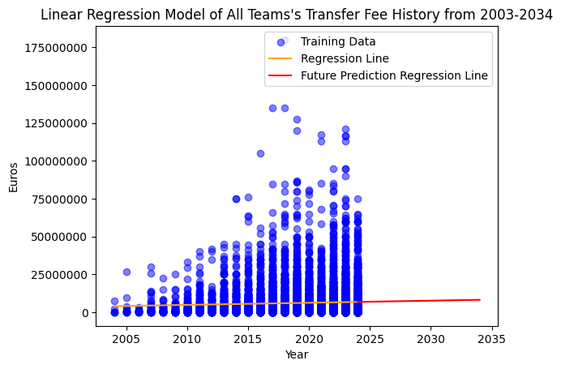

```python
all_Y_train_ten = all_teams_regression_model.predict(next_ten)

# Expanding the plot
plt.scatter(all_X, all_y, color='blue', label='Training Data', alpha=0.5)
plt.plot(all_X, all_Y_train_pred, color='orange', label='Regression Line')
plt.plot(next_ten, all_Y_train_ten, color='red', label='Future Prediction Regression Line')
plt.ticklabel_format(style='plain')
plt.title("Linear Regression Model of All Teams's Transfer Fee History from 2003-2034")
plt.xlabel("Year")
plt.ylabel("Euros")
plt.legend()
plt.show()
```

Now that we have these 3 different models, let's compare their results with each other for our final visualization

## Visualization

For this visualization, we want to put together all of the models to get an idea at which one is performing best. To do this, we're going to plot all of the Linear Regression models together alongside the actual average transfer value of the dataset over the years to see which one most accurately follows the true average

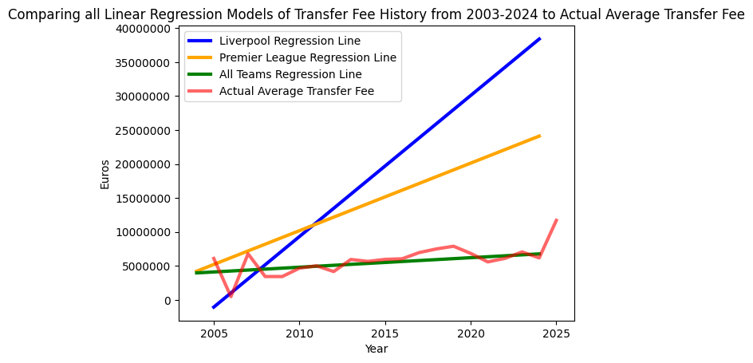

```python
# Plot the regression lines
plt.plot(liv_X, liv_Y_train_pred, color='blue', label='Liverpool Regression Line', linewidth=3)
plt.plot(prem_X, prem_Y_train_pred, color='orange', label='Premier League Regression Line', linewidth=3)
plt.plot(all_X, all_Y_train_pred, color='green', label='All Teams Regression Line', linewidth=3)
# Plot the true average transfer fee
plt.plot(fee_groups.mean(), label=("Actual Average Transfer Fee"), color='red', linewidth=3, alpha=0.6)
plt.ticklabel_format(style='plain')
plt.title("Comparing all Linear Regression Models of Transfer Fee History from 2003-2024 to Actual Average Transfer Fee")
plt.xlabel("Year")
plt.ylabel("Euros")
plt.legend()
plt.show()
```

Now, this may not be about basketball, but that is an absolute slam dunk for the All Teams Regression Line. It is immediately apparent that this is by some distance the best regression model for us to use out of the three Linear Regression models we utilized in terms of predicting future average transfer fees of future years for soccer players. We can now utilize this model to get a reasonable estimate for how much the average transfer will cost for a professional soccer player in the future, barring any monumental worldwide changes that any model would not be able to account for.

## Insights and Conclusions

With our Linear Regression model, we can now look out into the future and make a very educated guess on how much the average player will cost for any year going forward. For fun, let's quickly look 20 years into the future to see what our model predicts the average player will cost.

```python
# Return an array of the All Teams Linear Regression Model's prediction for 2044
all_teams_regression_model.predict(np.array([2044]).reshape(-1,1))
```

```
array([[9569055.25477076]])
```

Cool! Now we have a good estimate of roughly how much the cost of a player will be 20 years into the future! All based on a relatively straightforward Linear Regression model.

In more broad terms, this model also gives us a general idea of economic inflation throughout the years, and we can find that the rate of growth in these transfer fees is similar to the rate of inflation, however there are other catalysts that are independent of inflation that also contribute heavily, such as global popularity of the sport and TV rights deals.

Our final All Teams Linear Regression model is great for predicting the future average transfer value, but our other models also bring up extremely interesting avenues to explore. For instance, we could investigate individual teams that were promoted or relegated to a higher league and see how their graphs differ to those that have stayed in the highest league. Instinctively you might presume that the team that is staying steady in the highest league would be spending less, but that is not always the case. Many leagues have structures in place like "parachute payments" which are large sums of money to help relegated teams get back on their feet. Teams that are promoted to a new league are also often far more incentivized to go out and spend a lot of money on players to try and stay in the league. Knowing this, using a model like this can be remarkably effective at stabilizing the predictions of future costs, and would certainly help in finding outliers (like clubs that consistently pay larger fees than others) which you can then compare to their sporting success to see if there is a positive correlation to bigger spending. If there isn't, it may be time for that team's scouting department to get back to class!

These models (and the ability to modify them for a multitude of different inquiries), provide a great basis for analyzing historical transfer values and predicting the future of transfer datasets that they are given.